# Randomized Block Design key

John Shorter

March/13/2024

# Load packages

```r
#the same ones we used last time
library(emmeans)
library(multcomp)
```

```r
library(multcompView)
library(ggplot2)
library(tidyr)
library(dplyr)
library(readr)
library(readxl)
library(RColorBrewer)
library(viridis)
```

# Visualize data

```r
head(OrchardSprays)
```

```
##   decrease rowpos colpos treatment
## 1       57      1      1         D
## 2       95      2      1         E
## 3        8      3      1         B
## 4       69      4      1         H
## 5       92      5      1         G
## 6       90      6      1         F
```

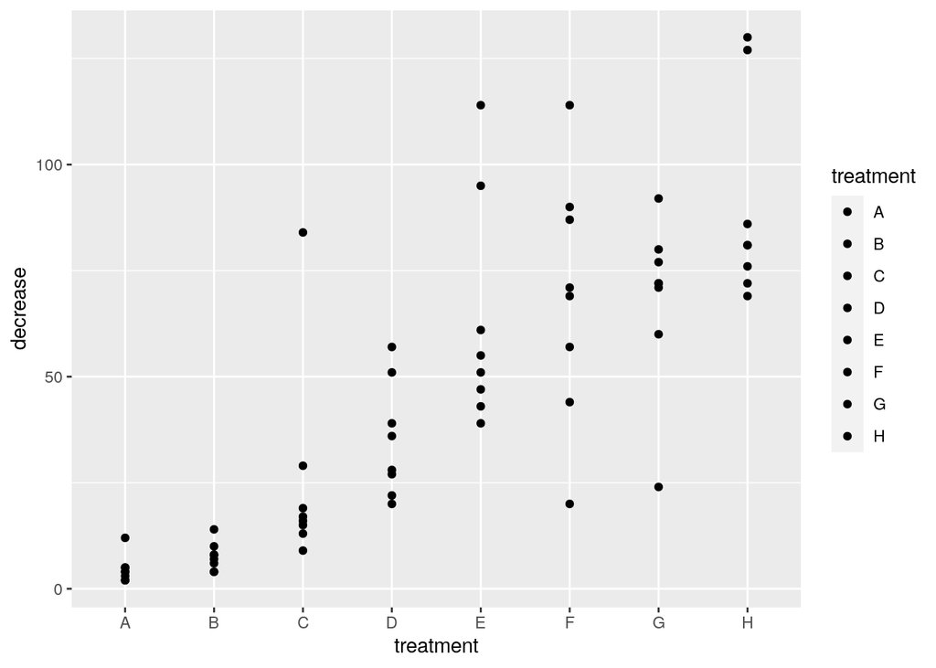

```r
#Very simple one
OrchardSprays %>%
  ggplot(aes(x = treatment , y = decrease)) +
  geom_point(aes(fill = treatment ))
```

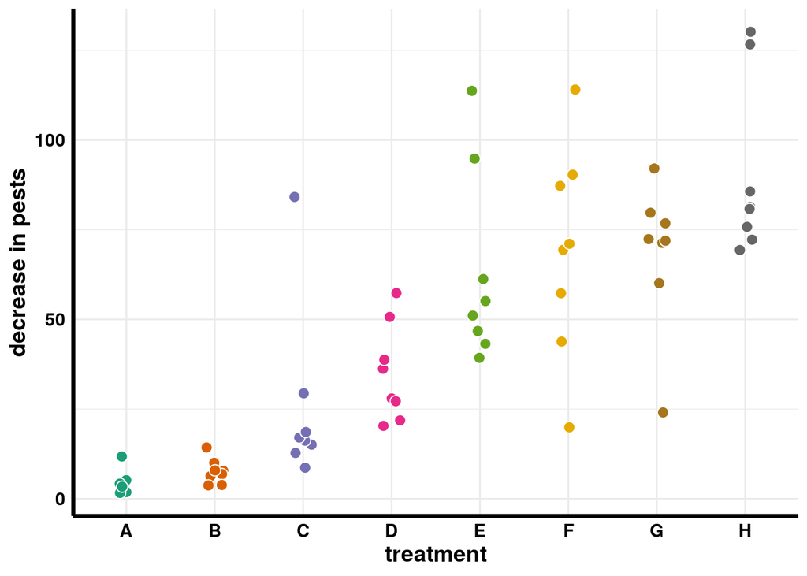

```r
#Publication quality one
OrchardSprays %>%
  ggplot(aes(x = treatment, y = decrease)) +
  geom_point(aes(fill = treatment), size = 3, color = "white", shape = 21,
             position = position_jitter(0.1, seed = 666)) +
  scale_fill_brewer(type = "qual", palette = "Dark2") +
  labs(y = "decrease in pests") +
  theme_minimal() +
  theme(
    axis.line = element_line(size = 1.2),
    text = element_text(size = 14, color = "black", face = "bold"),
    axis.text = element_text(color = "black"),
    legend.position = "none"
  )
```

# Exercise

Now you have learned how to analyze randomized block experiments. Let’s practice that!

This time we will look at an actual experiment

```r
chicken_experiment <- read_csv("/work/Data/Rmodule_data/betacarotenoid.csv")
head(chicken_experiment)
```

```
## # A tibble: 6 × 3
##   Field Pasture  Beta
##   <chr> <chr>   <dbl>
## 1 F1    P1       3.63
## 2 F1    P2       3.49
## 3 F1    P3       3.84
## 4 F1    P4       4.6
## 5 F1    P5       5.32
## 6 F2    P1       3.81
```

The researcher was testing the effect of different pastures (P1 to P5) on the amount of beta-carotene in egg. There were 4 fields (F1 - F4). The fields are the blocking factors. In each field, hens were randomly assigned to be fed with one of the 5 pastures. At the end of the experiment, eggs were collected and beta-carotene concentration was assayed. (Data from UC Davis Plant Sciences course PLS205, Winter 2017)

## Visualize the data

make the best plot you can to visualize the data.

What to put on x axis? What to color/fill with? You don’t have to include blocking factors in the plot

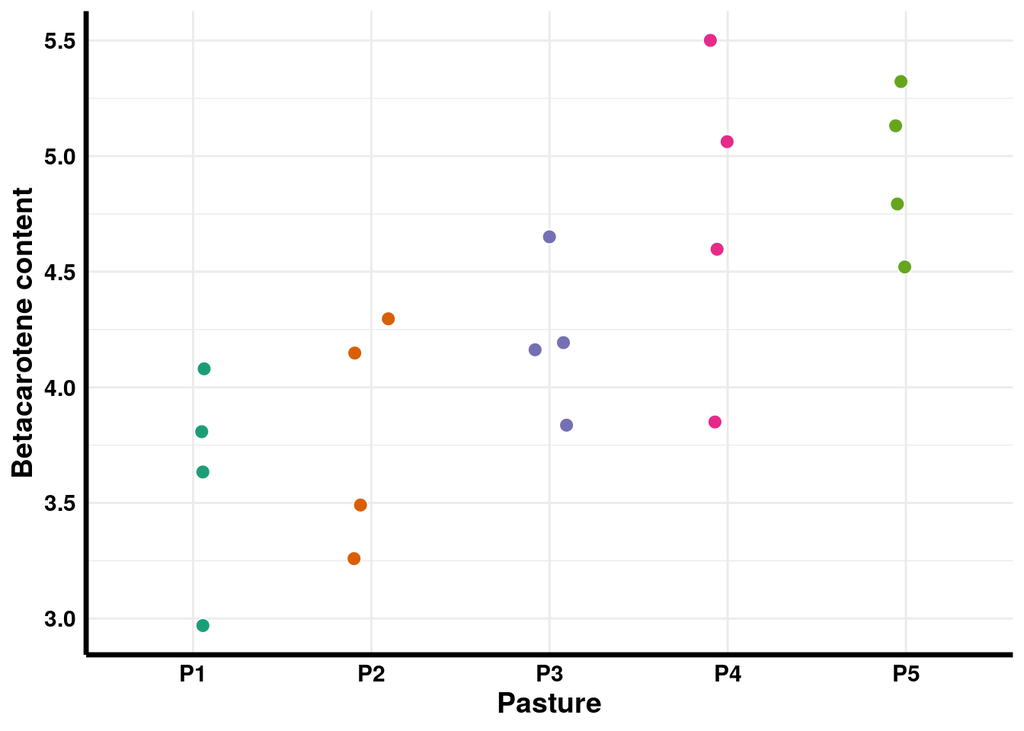

```r
chicken_experiment %>%
  ggplot(aes(x = Pasture, y = Beta)) +
  geom_point(aes(fill = Pasture), size = 3, color = "white", shape = 21,
             position = position_jitter(0.1, seed = 666)) +
  scale_fill_brewer(type = "qual", palette = "Dark2") +
  labs(y = "Betacarotene content") +
  theme_minimal() +
  theme(
    axis.line = element_line(size = 1.2),
    text = element_text(size = 14, color = "black", face = "bold"),
    axis.text = element_text(color = "black"),
    legend.position = "none"
  )
```

## Setting up the model

Fill out the table:

What are the sources of variation? What factors are they? (treatment? block? observational units? experimental units?) How many levels in each?

| source | factor | levels |
| --- | --- | --- |
| Pature | treatment | 5 |
| Field | block | 4 |
| Hen | EU | 20 |
| Egg | OU | 20 |

What should you include in the model? Set up the linear model.

```r
model_beta <- lm(Beta ~ Pasture + Field, data = chicken_experiment)
```

## Check assumptions of ANOVA

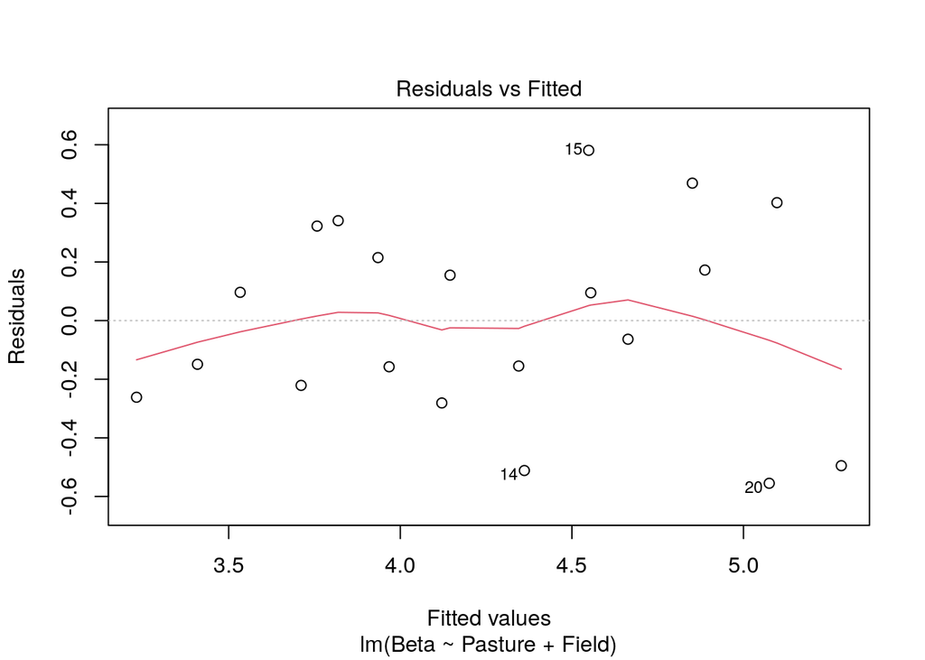

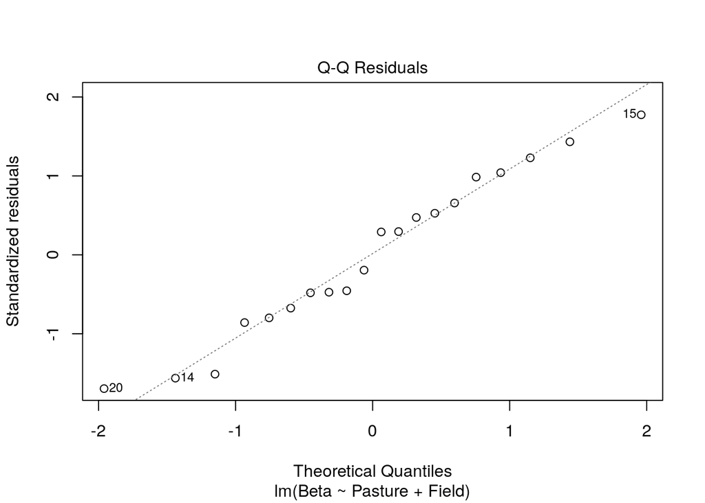

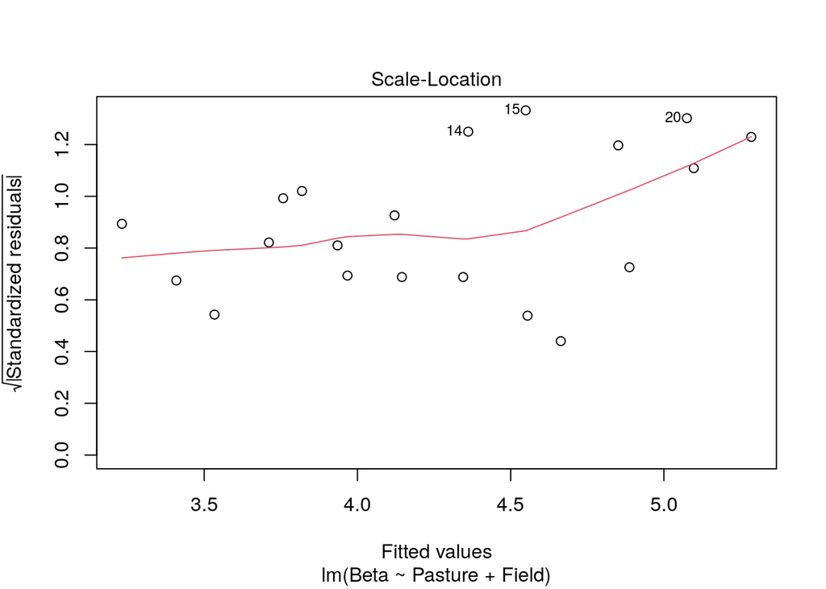

```r
plot(model_beta, which = c(1, 2, 3))
```

Normality? Pretty good. Equal variance? There might be a bit more variance at the higher end of fitted values. You can try a log transformation, but I don’t think it is very critical here.

## Run ANOVA

How would you interpret the ANOVA table?

```r
anova(model_beta)
```

```
## Analysis of Variance Table
##
## Response: Beta
##           Df Sum Sq Mean Sq F value   Pr(>F)
## Pasture    4 5.3013 1.32534  7.4176 0.003007 **
## Field      3 1.4903 0.49675  2.7802 0.086708 .
## Residuals 12 2.1441 0.17867
## ---
## Signif. codes:  0 '***' 0.001 '**' 0.01 '*' 0.05 '.' 0.1 ' ' 1
```

Fields did not contributed much to the variation. The means are statistically different across different pastures.

## Run Tukey tests and show cld

```r
estimate_beta <- emmeans(model_beta, pairwise ~ Pasture)
cld(estimate_beta$emmean, Letters = letters)
```

```
##  Pasture emmean    SE df lower.CL upper.CL .group
##  P1        3.62 0.211 12     3.16     4.08  a
##  P2        3.80 0.211 12     3.34     4.26  ab
##  P3        4.21 0.211 12     3.75     4.67  abc
##  P4        4.75 0.211 12     4.29     5.21   bc
##  P5        4.94 0.211 12     4.48     5.40    c
##
## Results are averaged over the levels of: Field
## Confidence level used: 0.95
## P value adjustment: tukey method for comparing a family of 5 estimates
## significance level used: alpha = 0.05
## NOTE: If two or more means share the same grouping symbol,
##       then we cannot show them to be different.
##       But we also did not show them to be the same.
```

Which pasture treatment gave the best beta-carotene content?

P5 is the highest, although not significantly different from P4 and P3, which all shares the letter c.